# Classification Modeling

Choonghyun Ryu

2021-02-22

## Preface

Once the data set is ready for model development, the model is fitted, predicted and evaluated in the following ways:

- Cleansing the dataset
- Split the data into a train set and a test set
- **Modeling and Evaluate, Predict**
  - **Modeling**
    - **Binary classification modeling**
  - **Evaluate the model**
    - **Predict test set using fitted model**
    - **Calculate the performance metric**
    - **Plot the ROC curve**
    - **Tunning the cut-off**
  - **Predict**
    - **Predict**
    - **Predict with cut-off**

The alookr package makes these steps fast and easy:

## Data: Wisconsin Breast Cancer Data

`BreastCancer` of `mlbench package` is a breast cancer data. The objective is to identify each of a number of benign or malignant classes.

A data frame with 699 observations on 11 variables, one being a character variable, 9 being ordered or nominal, and 1 target class.:

- `Id` : character. Sample code number
- `Cl.thickness` : ordered factor. Clump Thickness
- `Cell.size` : ordered factor. Uniformity of Cell Size
- `Cell.shape` : ordered factor. Uniformity of Cell Shape
- `Marg.adhesion` : ordered factor. Marginal Adhesion
- `Epith.c.size` : ordered factor. Single Epithelial Cell Size
- `Bare.nuclei` : factor. Bare Nuclei
- `Bl.cromatin` : factor. Bland Chromatin
- `Normal.nucleoli` : factor. Normal Nucleoli
- `Mitoses` : factor. Mitoses
- `Class` : factor. Class. level is `benign` and `malignant`.

```r
library(mlbench)
data(BreastCancer)

# class of each variables
sapply(BreastCancer, function(x) class(x)[1])
             Id    Cl.thickness       Cell.size      Cell.shape   Marg.adhesion
    "character"       "ordered"       "ordered"       "ordered"       "ordered"
   Epith.c.size     Bare.nuclei     Bl.cromatin Normal.nucleoli         Mitoses
      "ordered"        "factor"        "factor"        "factor"        "factor"
          Class
       "factor"
```

## Preperation the data

Perform data preprocessing as follows.:

- Find and imputate variables that contain missing values.
- Split the data into a train set and a test set.
- To solve the imbalanced class, perform sampling in the train set of raw data.
- Cleansing the dataset for classification modeling.

### Fix the missing value with `dlookr::imputate_na()`

find the variables that include missing value. and imputate the missing value using imputate_na() in dlookr package.

```r
library(dlookr)
library(dplyr)

# variable that have a missing value
diagnose(BreastCancer) %>%
  filter(missing_count > 0)
# A tibble: 1 x 6
  variables   types  missing_count missing_percent unique_count unique_rate
  <chr>       <chr>          <int>           <dbl>        <int>       <dbl>
1 Bare.nuclei factor            16            2.29           11      0.0157

# imputation of missing value
breastCancer <- BreastCancer %>%
  mutate(Bare.nuclei = imputate_na(BreastCancer, Bare.nuclei, Class,
                         method = "mice", no_attrs = TRUE, print_flag = FALSE))
```

## Split data set

### Splits the dataset into a train set and a test set with `split_by()`

`split_by()` in the alookr package splits the dataset into a train set and a test set.

The ratio argument of the `split_by()` function specifies the ratio of the train set.

`split_by()` creates a class object named split_df.

```r
library(alookr)

# split the data into a train set and a test set by default arguments
sb <- breastCancer %>%
  split_by(target = Class)

# show the class name
class(sb)
[1] "split_df"   "grouped_df" "tbl_df"     "tbl"        "data.frame"

# split the data into a train set and a test set by ratio = 0.6
tmp <- breastCancer %>%
  split_by(Class, ratio = 0.6)
```

The `summary()` function displays the following useful information about the split_df object:

- random seed : The random seed is the random seed used internally to separate the data
- split data : Information of splited data
  - train set count : number of train set
  - test set count : number of test set
- target variable : Target variable name
  - minority class : name and ratio(In parentheses) of minority class
  - majority class : name and ratio(In parentheses) of majority class

```r
# summary() display the some information
summary(sb)
** Split train/test set information **
 + random seed        :  13917
 + split data
    - train set count :  489
    - test set count  :  210
 + target variable    :  Class
    - minority class  :  malignant (0.344778)
    - majority class  :  benign (0.655222)

# summary() display the some information
summary(tmp)
** Split train/test set information **
 + random seed        :  36811
 + split data
    - train set count :  419
    - test set count  :  280
 + target variable    :  Class
    - minority class  :  malignant (0.344778)
    - majority class  :  benign (0.655222)
```

### Check missing levels in the train set

In the case of categorical variables, when a train set and a test set are separated, a specific level may be missing from the train set.

In this case, there is no problem when fitting the model, but an error occurs when predicting with the model you created. Therefore, preprocessing is performed to avoid missing data preprocessing.

In the following example, fortunately, there is no categorical variable that contains the missing levels in the train set.

```r
# list of categorical variables in the train set that contain missing levels
nolevel_in_train <- sb %>%
  compare_target_category() %>%
  filter(is.na(train)) %>%
  select(variable) %>%
  unique() %>%
  pull

nolevel_in_train
character(0)

# if any of the categorical variables in the train set contain a missing level,
# split them again.
while (length(nolevel_in_train) > 0) {
  sb <- breastCancer %>%
    split_by(Class)

  nolevel_in_train <- sb %>%
    compare_target_category() %>%
    filter(is.na(train)) %>%
    select(variable) %>%
    unique() %>%
    pull
}
```

## Handling the imbalanced classes data with `sampling_target()`

### Issue of imbalanced classes data

Imbalanced classes(levels) data means that the number of one level of the frequency of the target variable is relatively small. In general, the proportion of positive classes is relatively small. For example, in the model of predicting spam, the class of interest spam is less than non-spam.

Imbalanced classes data is a common problem in machine learning classification.

`table()` and `prop.table()` are traditionally useful functions for diagnosing imbalanced classes data. However, alookr’s `summary()` is simpler and provides more information.

```r
# train set frequency table - imbalanced classes data
table(sb$Class)

   benign malignant
      458       241

# train set relative frequency table - imbalanced classes data
prop.table(table(sb$Class))

   benign malignant
0.6552217 0.3447783

# using summary function - imbalanced classes data
summary(sb)
** Split train/test set information **
 + random seed        :  13917
 + split data
    - train set count :  489
    - test set count  :  210
 + target variable    :  Class
    - minority class  :  malignant (0.344778)
    - majority class  :  benign (0.655222)
```

### Handling the imbalanced classes data

Most machine learning algorithms work best when the number of samples in each class are about equal. And most algorithms are designed to maximize accuracy and reduce error. So, we requre handling an imbalanced class problem.

sampling_target() performs sampling to solve an imbalanced classes data problem.

### Resampling - oversample minority class

Oversampling can be defined as adding more copies of the minority class.

Oversampling is performed by specifying “ubOver” in the method argument of the `sampling_target()` function.

```r
# to balanced by over sampling
train_over <- sb %>%
  sampling_target(method = "ubOver")

# frequency table
table(train_over$Class)

   benign malignant
      322       322
```

### Resampling - undersample majority class

Undersampling can be defined as removing some observations of the majority class.

Undersampling is performed by specifying “ubUnder” in the method argument of the `sampling_target()` function.

```r
# to balanced by under sampling
train_under <- sb %>%
  sampling_target(method = "ubUnder")

# frequency table
table(train_under$Class)

   benign malignant
      167       167
```

### Generate synthetic samples - SMOTE

SMOTE(Synthetic Minority Oversampling Technique) uses a nearest neighbors algorithm to generate new and synthetic data.

SMOTE is performed by specifying “ubSMOTE” in the method argument of the `sampling_target()` function.

```r
# to balanced by SMOTE
train_smote <- sb %>%
  sampling_target(seed = 1234L, method = "ubSMOTE")

# frequency table
table(train_smote$Class)

   benign malignant
      668       501
```

## Cleansing the dataset for classification modeling with `cleanse()`

The `cleanse()` cleanse the dataset for classification modeling.

This function is useful when fit the classification model. This function does the following.:

- Remove the variable with only one value.
- And remove variables that have a unique number of values relative to the number of observations for a character or categorical variable.
  - In this case, it is a variable that corresponds to an identifier or an identifier.
- And converts the character to factor.

In this example, The `cleanse()` function removed a variable ID with a high unique rate.

```r
# clean the training set
train <- train_smote %>%
  cleanse
── Checking unique value ─────────────────────────── unique value is one ──
No variables that unique value is one.

── Checking unique rate ─────────────────────────────── high unique rate ──
remove variables with high unique rate
● Id = 423(0.361847733105218)

── Checking character variables ─────────────────────── categorical data ──
No character variables.
```

## Extract test set for evaluation of the model with `extract_set()`

```r
# extract test set
test <- sb %>%
  extract_set(set = "test")
```

## Binary classification modeling with `run_models()`

`run_models()` performs some representative binary classification modeling using `split_df` object created by `split_by()`.

`run_models()` executes the process in parallel when fitting the model. However, it is not supported in MS-Windows operating system and RStudio environment.

Currently supported algorithms are as follows.:

- logistic : logistic regression using `stats` package
- rpart : Recursive Partitioning Trees using `rpart` package
- ctree : Conditional Inference Trees using `party` package
- randomForest :Classification with Random Forest using `randomForest` package
- ranger : A Fast Implementation of Random Forests using `ranger` package
- xgboost : Extreme Gradient Boosting using `xgboost` package

`run_models()` returns a `model_df` class object.

The `model_df` class object contains the following variables.:

- step : character. The current stage in the classification modeling process.
  - For objects created with `run_models()`, the value of the variable is “1.Fitted”.
- model_id : model identifiers
- target : name of target variable
- positive : positive class in target variable
- fitted_model : list. Fitted model object by model_id’s algorithms

```r
result <- train %>%
  run_models(target = "Class", positive = "malignant")
result
# A tibble: 6 x 7
  step     model_id     target is_factor positive  negative fitted_model
  <chr>    <chr>        <chr>  <lgl>     <chr>     <chr>    <list>
1 1.Fitted logistic     Class  TRUE      malignant benign   <glm>
2 1.Fitted rpart        Class  TRUE      malignant benign   <rpart>
3 1.Fitted ctree        Class  TRUE      malignant benign   <BinaryTr>
4 1.Fitted randomForest Class  TRUE      malignant benign   <rndmFrs.>
5 1.Fitted ranger       Class  TRUE      malignant benign   <ranger>
6 1.Fitted xgboost      Class  TRUE      malignant benign   <xgb.Bstr>
```

## Evaluate the model

Evaluate the predictive performance of fitted models.

### Predict test set using fitted model with `run_predict()`

`run_predict()` predict the test set using `model_df` class fitted by `run_models()`.

`run_predict ()` is executed in parallel when predicting by model. However, it is not supported in MS-Windows operating system and RStudio environment.

The `model_df` class object contains the following variables.:

- step : character. The current stage in the classification modeling process.
  - For objects created with `run_predict()`, the value of the variable is “2.Predicted”.
- model_id : character. Type of fit model.
- target : character. Name of target variable.
- positive : character. Level of positive class of binary classification.
- fitted_model : list. Fitted model object by model_id’s algorithms.
- predicted : result of predcit by each models

```r
pred <- result %>%
  run_predict(test)
pred
# A tibble: 6 x 8
  step     model_id   target is_factor positive  negative fitted_model predicted
  <chr>    <chr>      <chr>  <lgl>     <chr>     <chr>    <list>       <list>
1 2.Predi… logistic   Class  TRUE      malignant benign   <glm>        <fct [21…
2 2.Predi… rpart      Class  TRUE      malignant benign   <rpart>      <fct [21…
3 2.Predi… ctree      Class  TRUE      malignant benign   <BinaryTr>   <fct [21…
4 2.Predi… randomFor… Class  TRUE      malignant benign   <rndmFrs.>   <fct [21…
5 2.Predi… ranger     Class  TRUE      malignant benign   <ranger>     <fct [21…
6 2.Predi… xgboost    Class  TRUE      malignant benign   <xgb.Bstr>   <fct [21…
```

### Calculate the performance metric with `run_performance()`

`run_performance()` calculate the performance metric of `model_df` class predicted by `run_predict()`.

`run_performance ()` is performed in parallel when calculating the performance evaluation metrics However, it is not supported in MS-Windows operating system and RStudio environment.

The `model_df` class object contains the following variables.:

- step : character. The current stage in the classification modeling process.
  - For objects created with `run_performance()`, the value of the variable is “3.Performanced”.
- model_id : character. Type of fit model.
- target : character. Name of target variable.
- positive : character. Level of positive class of binary classification.
- fitted_model : list. Fitted model object by model_id’s algorithms
- predicted : list. Predicted value by individual model. Each value has a predict_class class object.
- performance : list. Calculate metrics by individual model. Each value has a numeric vector.

```r
# Calculate performace metrics.
perf <- run_performance(pred)
perf
# A tibble: 6 x 7
  step          model_id     target positive fitted_model predicted  performance
  <chr>         <chr>        <chr>  <chr>    <list>       <list>     <list>
1 3.Performanc… logistic     Class  maligna… <glm>        <fct [210… <dbl [15]>
2 3.Performanc… rpart        Class  maligna… <rpart>      <fct [210… <dbl [15]>
3 3.Performanc… ctree        Class  maligna… <BinaryTr>   <fct [210… <dbl [15]>
4 3.Performanc… randomForest Class  maligna… <rndmFrs.>   <fct [210… <dbl [15]>
5 3.Performanc… ranger       Class  maligna… <ranger>     <fct [210… <dbl [15]>
6 3.Performanc… xgboost      Class  maligna… <xgb.Bstr>   <fct [210… <dbl [15]>
```

The performance variable contains a list object, which contains 15 performance metrics:

- ZeroOneLoss : Normalized Zero-One Loss(Classification Error Loss).
- Accuracy : Accuracy.
- Precision : Precision.
- Recall : Recall.
- Sensitivity : Sensitivity.
- Specificity : Specificity.
- F1_Score : F1 Score.
- Fbeta_Score : F-Beta Score.
- LogLoss : Log loss / Cross-Entropy Loss.
- AUC : Area Under the Receiver Operating Characteristic Curve (ROC AUC).
- Gini : Gini Coefficient.
- PRAUC : Area Under the Precision-Recall Curve (PR AUC).
- LiftAUC : Area Under the Lift Chart.
- GainAUC : Area Under the Gain Chart.
- KS_Stat : Kolmogorov-Smirnov Statistic.

```r
# Performance by analytics models
performance <- perf$performance
names(performance) <- perf$model_id
performance
$logistic
ZeroOneLoss    Accuracy   Precision      Recall Sensitivity Specificity
 0.06666667  0.93333333  0.90540541  0.90540541  0.90540541  0.94852941
   F1_Score Fbeta_Score     LogLoss         AUC        Gini       PRAUC
 0.90540541  0.90540541  2.21573578  0.93203498  0.89467409  0.07393676
    LiftAUC     GainAUC     KS_Stat
 1.15216418  0.77979408 86.00953895

$rpart
ZeroOneLoss    Accuracy   Precision      Recall Sensitivity Specificity
 0.05238095  0.94761905  0.87951807  0.98648649  0.98648649  0.92647059
   F1_Score Fbeta_Score     LogLoss         AUC        Gini       PRAUC
 0.92993631  0.92993631  0.18277371  0.95637917  0.93203498  0.92193313
    LiftAUC     GainAUC     KS_Stat
 2.04562907  0.79555985 91.29570747

$ctree
ZeroOneLoss    Accuracy   Precision      Recall Sensitivity Specificity
 0.07619048  0.92380952  0.89189189  0.89189189  0.89189189  0.94117647
   F1_Score Fbeta_Score     LogLoss         AUC        Gini       PRAUC
 0.89189189  0.89189189  1.07973081  0.96383148  0.92865660  0.27405684
    LiftAUC     GainAUC     KS_Stat
 1.36782882  0.80038610 91.41494436

$randomForest
ZeroOneLoss    Accuracy   Precision      Recall Sensitivity Specificity
 0.03809524  0.96190476  0.90243902  1.00000000  1.00000000  0.94117647
   F1_Score Fbeta_Score     LogLoss         AUC        Gini       PRAUC
 0.94871795  0.94871795  0.27214718  0.98405207  0.96562003  0.62730006
    LiftAUC     GainAUC     KS_Stat
 1.70832080  0.81348134 94.85294118

$ranger
ZeroOneLoss    Accuracy   Precision      Recall Sensitivity Specificity
 0.03333333  0.96666667  0.92405063  0.98648649  0.98648649  0.95588235
   F1_Score Fbeta_Score     LogLoss         AUC        Gini       PRAUC
 0.95424837  0.95424837  0.10848139  0.99036169  0.98072337  0.80215934
    LiftAUC     GainAUC     KS_Stat
 1.87863357  0.81756757 94.85294118

$xgboost
ZeroOneLoss    Accuracy   Precision      Recall Sensitivity Specificity
 0.03333333  0.96666667  0.92405063  0.98648649  0.98648649  0.95588235
   F1_Score Fbeta_Score     LogLoss         AUC        Gini       PRAUC
 0.95424837  0.95424837  0.09892333  0.99264706  0.98469793  0.88976500
    LiftAUC     GainAUC     KS_Stat
 1.99708831  0.81904762 94.97217806
```

If you change the list object to tidy format, you’ll see the following at a glance:

```r
# Convert to matrix for compare performace.
sapply(performance, "c")
               logistic       rpart       ctree randomForest      ranger
ZeroOneLoss  0.06666667  0.05238095  0.07619048   0.03809524  0.03333333
Accuracy     0.93333333  0.94761905  0.92380952   0.96190476  0.96666667
Precision    0.90540541  0.87951807  0.89189189   0.90243902  0.92405063
Recall       0.90540541  0.98648649  0.89189189   1.00000000  0.98648649
Sensitivity  0.90540541  0.98648649  0.89189189   1.00000000  0.98648649
Specificity  0.94852941  0.92647059  0.94117647   0.94117647  0.95588235
F1_Score     0.90540541  0.92993631  0.89189189   0.94871795  0.95424837
Fbeta_Score  0.90540541  0.92993631  0.89189189   0.94871795  0.95424837
LogLoss      2.21573578  0.18277371  1.07973081   0.27214718  0.10848139
AUC          0.93203498  0.95637917  0.96383148   0.98405207  0.99036169
Gini         0.89467409  0.93203498  0.92865660   0.96562003  0.98072337
PRAUC        0.07393676  0.92193313  0.27405684   0.62730006  0.80215934
LiftAUC      1.15216418  2.04562907  1.36782882   1.70832080  1.87863357
GainAUC      0.77979408  0.79555985  0.80038610   0.81348134  0.81756757
KS_Stat     86.00953895 91.29570747 91.41494436  94.85294118 94.85294118
                xgboost
ZeroOneLoss  0.03333333
Accuracy     0.96666667
Precision    0.92405063
Recall       0.98648649
Sensitivity  0.98648649
Specificity  0.95588235
F1_Score     0.95424837
Fbeta_Score  0.95424837
LogLoss      0.09892333
AUC          0.99264706
Gini         0.98469793
PRAUC        0.88976500
LiftAUC      1.99708831
GainAUC      0.81904762
KS_Stat     94.97217806
```

`compare_performance()` return a list object(results of compared model performance). and list has the following components:

- recommend_model : character. The name of the model that is recommended as the best among the various models.
- top_count : numeric. The number of best performing performance metrics by model.
- mean_rank : numeric. Average of ranking individual performance metrics by model.
- top_metric : list. The name of the performance metric with the best performance on individual performance metrics by model.

```r
# Compaire the Performance metrics of each model
comp_perf <- compare_performance(pred)
comp_perf
$recommend_model
[1] "xgboost"

$top_metric_count
    logistic        rpart        ctree randomForest       ranger      xgboost
           0            2            0            1            5           10

$mean_rank
    logistic        rpart        ctree randomForest       ranger      xgboost
    5.230769     3.923077     5.038462     3.230769     2.076923     1.500000

$top_metric
$top_metric$logistic
NULL

$top_metric$rpart
[1] "PRAUC"   "LiftAUC"

$top_metric$ctree
NULL

$top_metric$randomForest
[1] "Recall"

$top_metric$ranger
[1] "ZeroOneLoss" "Accuracy"    "Precision"   "Specificity" "F1_Score"

$top_metric$xgboost
 [1] "ZeroOneLoss" "Accuracy"    "Precision"   "Specificity" "F1_Score"
 [6] "LogLoss"     "AUC"         "Gini"        "GainAUC"     "KS_Stat"
```

### Plot the ROC curve with `plot_performance()`

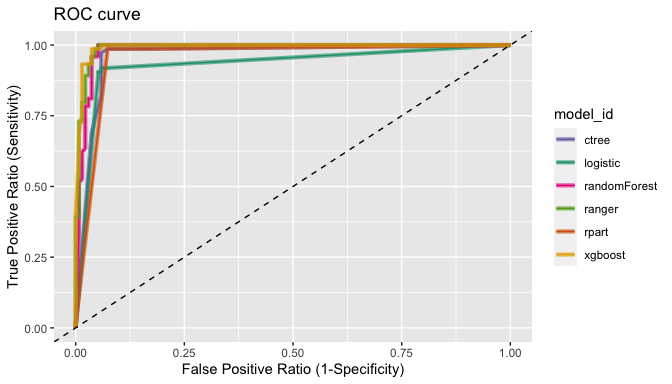

```r
# Plot ROC curve
plot_performance(pred)
```

### Tunning the cut-off

In general, if the prediction probability is greater than 0.5 in the binary classification model, it is predicted as `positive class`. In other words, 0.5 is used for the cut-off value. This applies to most model algorithms. However, in some cases, the performance can be tuned by changing the cut-off value.

`plot_cutoff ()` visualizes a plot to select the cut-off value, and returns the cut-off value.

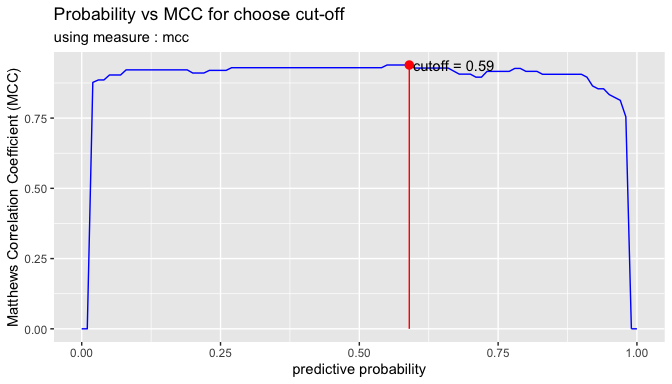

```r
pred_best <- pred %>%
  filter(model_id == comp_perf$recommend_model) %>%
  select(predicted) %>%
  pull %>%
  .[[1]] %>%
  attr("pred_prob")

cutoff <- plot_cutoff(pred_best, test$Class, "malignant", type = "mcc")
```

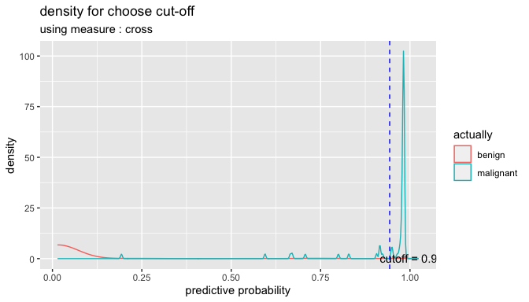

```r
cutoff
[1] 0.59

cutoff2 <- plot_cutoff(pred_best, test$Class, "malignant", type = "density")
```

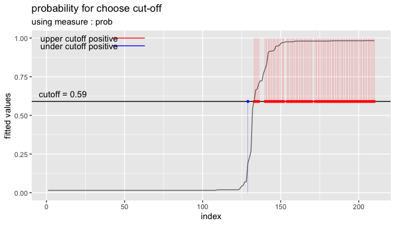

```r
cutoff2
[1] 0.9432

cutoff3 <- plot_cutoff(pred_best, test$Class, "malignant", type = "prob")
```

```r
cutoff3
[1] 0.59
```

### Performance comparison between prediction and tuned cut-off with `performance_metric()`

Compare the performance of the original prediction with that of the tuned cut-off. Compare the cut-off with the non-cut model for the model with the best performance `comp_perf$recommend_model`.

```r
comp_perf$recommend_model
[1] "xgboost"

# extract predicted probability
idx <- which(pred$model_id == comp_perf$recommend_model)
pred_prob <- attr(pred$predicted[[idx]], "pred_prob")

# or, extract predicted probability using dplyr
pred_prob <- pred %>%
  filter(model_id == comp_perf$recommend_model) %>%
  select(predicted) %>%
  pull %>%
  "[["(1) %>%
  attr("pred_prob")

# predicted probability
pred_prob
  [1] 0.01535552 0.98275143 0.98050195 0.01535552 0.01535552 0.94856179
  [7] 0.91705197 0.97572815 0.98050195 0.98050195 0.01535552 0.01535552
 [13] 0.01535552 0.01884205 0.01535552 0.98325688 0.01535552 0.01535552
 [19] 0.66540080 0.94856179 0.01535552 0.96420807 0.98325688 0.01535552
 [25] 0.01535552 0.97572815 0.98238224 0.01535552 0.01535552 0.98275143
 [31] 0.01884205 0.70717180 0.98275143 0.01535552 0.01535552 0.98275143
 [37] 0.01535552 0.01896222 0.01535552 0.01535552 0.01535552 0.01535552
 [43] 0.98050195 0.97572815 0.01535552 0.98275143 0.98050195 0.01535552
 [49] 0.98050195 0.01535552 0.98066860 0.01884205 0.98275143 0.01535552
 [55] 0.98050195 0.98050195 0.98325688 0.98050195 0.98275143 0.98238224
 [61] 0.01535552 0.07017319 0.01535552 0.98050195 0.98008555 0.72390038
 [67] 0.98050195 0.98008555 0.98275143 0.98275143 0.98275143 0.79972100
 [73] 0.01884205 0.01535552 0.98275143 0.01535552 0.98275143 0.98275143
 [79] 0.01535552 0.01535552 0.97572815 0.54601741 0.90654624 0.98050195
 [85] 0.01535552 0.01535552 0.98275143 0.07017319 0.97051674 0.01535552
 [91] 0.77255034 0.98238224 0.01535552 0.01535552 0.01535552 0.01535552
 [97] 0.59456104 0.95144945 0.01535552 0.01535552 0.98275143 0.98325688
[103] 0.92347544 0.01896222 0.22600374 0.01535552 0.01535552 0.01535552
[109] 0.01535552 0.01535552 0.01535552 0.01535552 0.01535552 0.98050195
[115] 0.01535552 0.98325688 0.04800571 0.01896222 0.01535552 0.98050195
[121] 0.01535552 0.98050195 0.01535552 0.01884205 0.01896222 0.01535552
[127] 0.01535552 0.97572815 0.01535552 0.19303423 0.01535552 0.01535552
[133] 0.01535552 0.98275143 0.98050195 0.98325688 0.01535552 0.01535552
[139] 0.01535552 0.97572815 0.01535552 0.01740400 0.01535552 0.01896222
[145] 0.98275143 0.98325688 0.01535552 0.01535552 0.01535552 0.01535552
[151] 0.01535552 0.01535552 0.01535552 0.91522729 0.98050195 0.01535552
[157] 0.01535552 0.01884205 0.98008555 0.01535552 0.01535552 0.01535552
[163] 0.01535552 0.01535552 0.01535552 0.02708772 0.01535552 0.01535552
[169] 0.01535552 0.01535552 0.01535552 0.98008555 0.98050195 0.82886475
[175] 0.91522729 0.01535552 0.01884205 0.01535552 0.01535552 0.98275143
[181] 0.01535552 0.98275143 0.01535552 0.01884205 0.01535552 0.26949933
[187] 0.01535552 0.04251119 0.01535552 0.01535552 0.01535552 0.01535552
[193] 0.01535552 0.01535552 0.01535552 0.01535552 0.72390038 0.01535552
[199] 0.01884205 0.01535552 0.01535552 0.97076619 0.01535552 0.01535552
[205] 0.01535552 0.01535552 0.01535552 0.01535552 0.01535552 0.67065585

# compaire Accuracy
performance_metric(pred_prob, test$Class, "malignant", "Accuracy")
[1] 0.9666667
performance_metric(pred_prob, test$Class, "malignant", "Accuracy",
                   cutoff = cutoff)
[1] 0.9714286

# compaire Confusion Matrix
performance_metric(pred_prob, test$Class, "malignant", "ConfusionMatrix")
           actual
predict     benign malignant
  benign       130         1
  malignant      6        73
performance_metric(pred_prob, test$Class, "malignant", "ConfusionMatrix",
                   cutoff = cutoff)
           actual
predict     benign malignant
  benign       131         1
  malignant      5        73

# compaire F1 Score
performance_metric(pred_prob, test$Class, "malignant", "F1_Score")
[1] 0.9542484
performance_metric(pred_prob, test$Class,  "malignant", "F1_Score",
                   cutoff = cutoff)
[1] 0.9605263
performance_metric(pred_prob, test$Class,  "malignant", "F1_Score",
                   cutoff = cutoff2)
[1] 0.8985507
```

If the performance of the tuned cut-off is good, use it as a cut-off to predict positives.

## Predict

If you have selected a good model from several models, then perform the prediction with that model.

### Create data set for predict

```r
data_pred <- train_under %>%
  cleanse
── Checking unique value ─────────────────────────── unique value is one ──
No variables that unique value is one.

── Checking unique rate ─────────────────────────────── high unique rate ──
remove variables with high unique rate
● Id = 322(0.964071856287425)

── Checking character variables ─────────────────────── categorical data ──
No character variables.

set.seed(1234L)
data_pred <- data_pred %>%
  nrow %>%
  seq %>%
  sample(size = 50) %>%
  data_pred[., ]
```

### Predict with alookr and dplyr

Do a predict using the `dplyr` package. The last `factor()` function eliminates unnecessary information.

```r
pred_actual <- pred %>%
  filter(model_id == comp_perf$recommend_model) %>%
  run_predict(data_pred) %>%
  select(predicted) %>%
  pull %>%
  "[["(1) %>%
  factor()

pred_actual
 [1] malignant benign    benign    benign    benign    benign    benign
 [8] malignant benign    malignant benign    malignant benign    malignant
[15] benign    benign    benign    malignant malignant malignant malignant
[22] malignant malignant benign    malignant benign    malignant benign
[29] malignant benign    malignant benign    malignant malignant benign
[36] malignant benign    benign    malignant benign    benign    malignant
[43] malignant malignant malignant malignant benign    malignant benign
[50] benign
Levels: benign malignant
```

If you want to predict by cut-off, specify the `cutoff` argument in the `run_predict()` function as follows.:

```r
pred_actual2 <- pred %>%
  filter(model_id == comp_perf$recommend_model) %>%
  run_predict(data_pred, cutoff) %>%
  select(predicted) %>%
  pull %>%
  "[["(1) %>%
  factor()

pred_actual2
 [1] malignant benign    benign    benign    benign    benign    benign
 [8] malignant benign    malignant benign    malignant benign    malignant
[15] benign    benign    benign    malignant malignant malignant malignant
[22] malignant malignant benign    malignant benign    malignant benign
[29] malignant benign    malignant benign    malignant benign    benign
[36] malignant benign    benign    malignant benign    benign    malignant
[43] malignant malignant malignant malignant benign    malignant benign
[50] benign
Levels: benign malignant

sum(pred_actual != pred_actual2)
[1] 1
```